# 02-exercises

Christopher Brown

April 13, 2016

This exercise uses the **Fuel Economy** data set from the **AppliedPredicitiveModeling** package.

Note: The following will set-up your environment for this exercise. If you get an error stating that the packages have not been found, you need to install those packages.

## Exercise 1

Hint: See `?cars2010`

- After the **Fuel Economy** data is loaded, combine three data sets into one data set. (Note: The name `dat` is very often used in these situations, `data` is a reserved R word.)

```r
dat <- bind_rows( cars2010, cars2011, cars2012)    # Define
```

- What is a good “naive guess” of FE? Show your work

```r
naive_guess <- mean(dat$FE)
```

- plot FE (Fuel Econonomy) vs. EngDisp. Plot the naive guess.

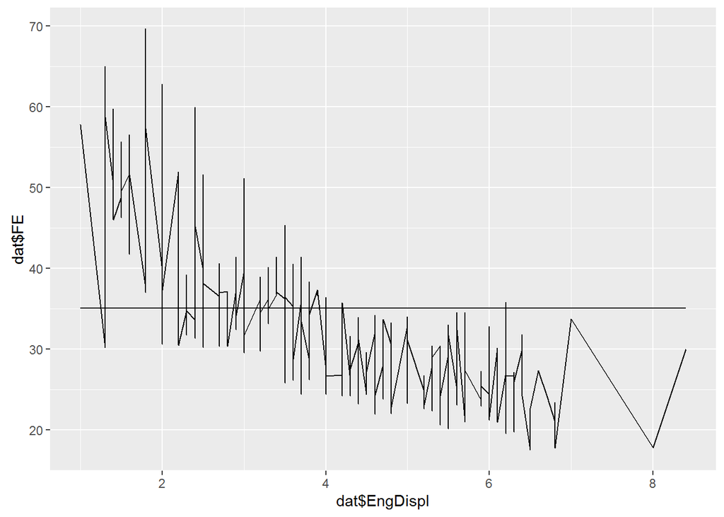

```r
 ggplot(dat,aes(y=dat$FE, x=dat$EngDispl))+geom_line()+geom_line(aes(y=mean(dat$FE)))
```

```r
set.seed(314)

# Sample
samp <- dat %>% dplyr::sample_n(10)
samp
```

```
## Source: local data frame [10 x 14]
##
##    EngDispl NumCyl Transmission      FE AirAspirationMethod NumGears
##       (dbl)  (int)       (fctr)   (dbl)              (fctr)    (int)
## 1       3.0      6           S6 36.1548        Turbocharged        6
## 2       3.0      6           M6 35.7081        Turbocharged        6
## 3       5.9     12           M6 22.9258  NaturallyAspirated        6
## 4       3.6      6           S6 35.6000  NaturallyAspirated        6
## 5       2.0      4           S5 46.6240  NaturallyAspirated        5
## 6       2.5      4           AV 51.6000  NaturallyAspirated        1
## 7       1.8      4           A4 48.4000  NaturallyAspirated        4
## 8       3.5      6           A4 34.2000  NaturallyAspirated        4
## 9       3.8      6           A6 31.9000  NaturallyAspirated        6
## 10      2.5      4           M5 37.0710  NaturallyAspirated        5
## Variables not shown: TransLockup (dbl), TransCreeperGear (dbl), DriveDesc
##   (fctr), IntakeValvePerCyl (int), ExhaustValvesPerCyl (int),
##   CarlineClassDesc (fctr), VarValveTiming (dbl), VarValveLift (dbl)
```

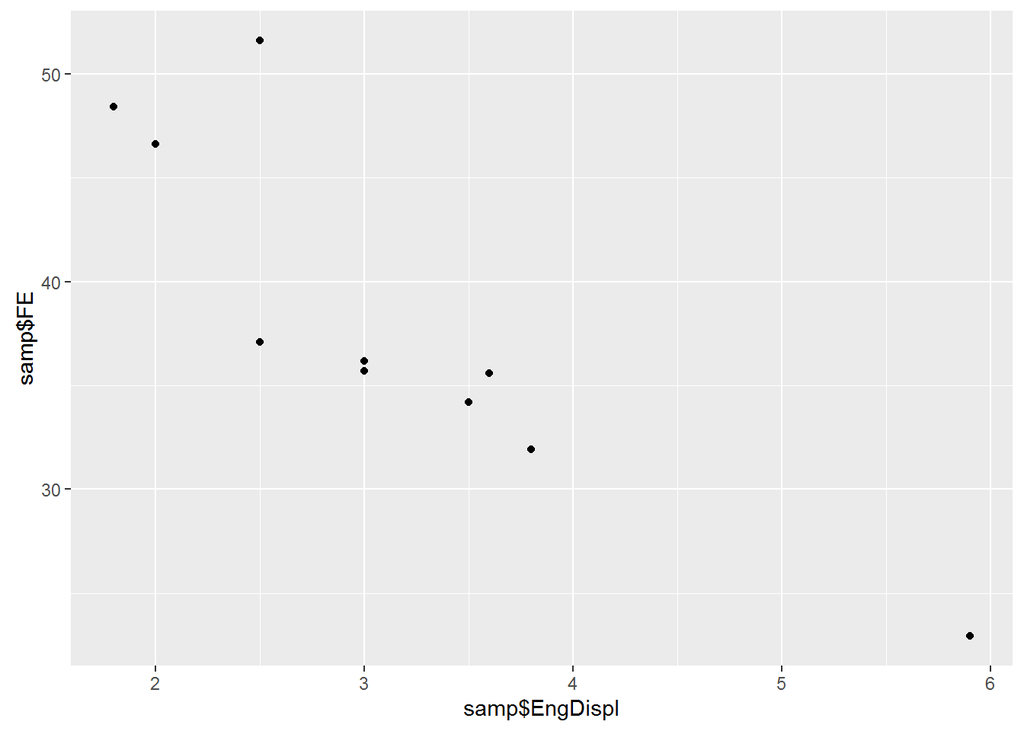

```r
# Plots

qplot(y=samp$FE, x=samp$EngDispl)
```

## Exercise 2:

Write a loss functions for calculating: - Root Mean Square Error - Mean Absolute Error - Median Absolute Error

All functions should accept two arguments:

```r
rmse <- function(y,yhat) {
  ( y - yhat )^2  %>% mean   %>% sqrt
}

mae <- function(y, yhat) {
  abs(y-yhat) %>% mean %>% sqrt
}

medae <- function(y, yhat) {
 abs(y-yhat) %>% median %>% sqrt
}

y=samp$FE
yhat=mean(dat$FE)
rmse(y,yhat)
```

```
## [1] 8.662936
```

```r
mae(y,yhat)
```

```
## [1] 2.489562
```

```r
medae(y,yhat)
```

```
## [1] 1.607949
```

Use these functions to evaluate the loss/performance of: - the naive guess

## Exercise 3: Linear Model and Model Performance

- Use `lm` to create a linear model fitting the relationship between FE and EngDispl for the cars2010 data set

```r
fit.2010 <- lm(FE~EngDispl,cars2010)
fit.2010
```

```
##
## Call:
## lm(formula = FE ~ EngDispl, data = cars2010)
##
## Coefficients:
## (Intercept)     EngDispl
##      50.563       -4.521
```

- Use your functions to evaluate the training error
- Use your model to: – predict the FE for 2011. What is the RMSE errors associated with the predictions. – predict the FE for 2012. What is the RMSE errors associated with the predictions.

```r
y.2010 <- predict(fit.2010,cars2010)
y.2011 <- predict(fit.2010,cars2011)
y.2012 <- predict(fit.2010,cars2012)

rmse.2010 <- rmse(cars2010$FE,y.2010)
rmse.2011 <- rmse(cars2011$FE,y.2011)
rmse.2012 <- rmse(cars2012$FE,y.2012)
```

```r
# DO NOT EDIT
rmse.2010
```

```
## [1] 4.620076
```

```r
rmse.2011
```

```
## [1] 5.162531
```

```r
rmse.2012
```

```
## [1] 6.63853
```

## Exercise 4:

```r
fit.2011 <- lm(cars2011$FE~cars2011$EngDispl+cars2011$NumCyl+cars2011$VarValveLift)
betas <- coef(fit.2011)
```